# Blackpoll Warbler

pdt

January 31, 2018

I have provided you with a data set on ACORN in RDS format. For this assignment, I would like you to re-produce the following plot. You will need to think about the problem carefully, and use your newly acquired tidyverse skills.

The data are the masses of individual blackpoll warblers banded (and recaptured) on Seal and Bon Portage Islands, Nova Scotia. One thing we are interested in is the patterns of mass gain during fall migration.

The data I am provided are as follows.

location: the location (Bon Portage or Seal Island; ABO-BP and ABO-SI respectively) band: the unique band number of each individual age: HY or AHY (whether the bird was born that year - HY or at least a year previously - AHY) recap: whether this instance of the bird’s capture was in fact a recapture year, month, day: the year, month and day of the particular capture or recapture.

Here is the plot. Each coloured line/point is an individual bird. Each point is the relative mass of an individual bird (with 0 being the relative mass at capture).

The plot shows the gain in mass of all of the recaptured birds through time. We can see that in the early fall, individuals don’t gain mass, that there seems to be a gap around mid-September (where we either don’t catch individual blackpolls, or at least we never recapture them), and it shows a pattern of individuals rapidly increasing mass starting in early October.

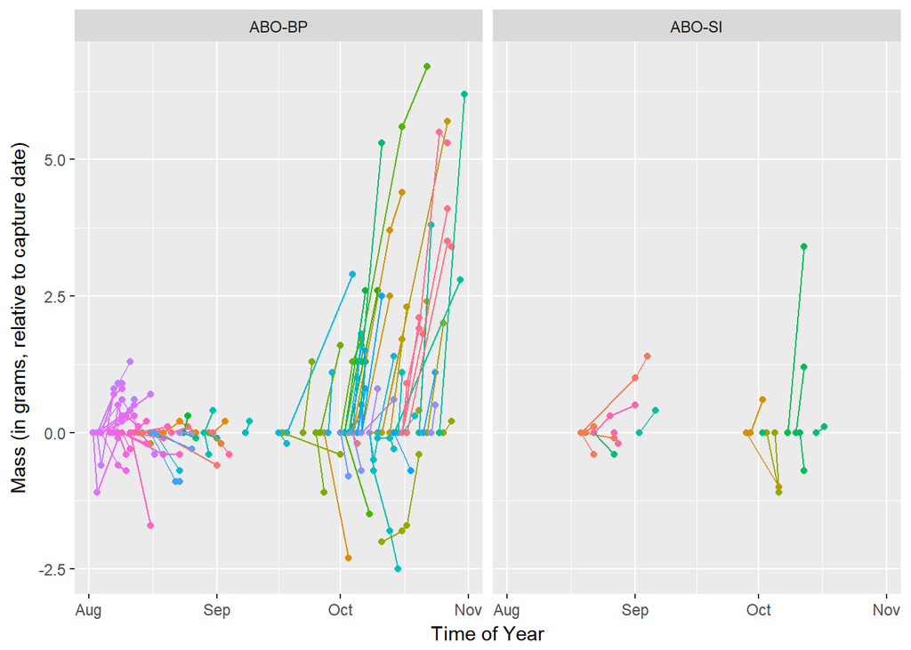